# Approximate maximum influence perturbations

Patrick Brown

2026-10-26

## Introduction

This vignette applies the approximate maximum influence perturbation (AMIP) of Broderick, Giordano, and Meager in two settings. After fitting, outer parameters (`beta`, `theta`) are held at the MLE and only the inner random effects `gamma` are allowed to move. Package helpers `phi_gamma()`, `influence_scores()`, `amip_set()`, and `ad_pack_drop()` cover the shared pipeline: the fit-time observation tapes supply the inner Hessian $H$; per-unit scores use streaming one-unit observation gradients (`grad_obs_units`) so scores do not require holding an identity shard pack.

The first example is the London case-crossover model: the most influential **strata** for flipping the PM10 effect at exposure 80. The second is the MASS `bacteria` Bernoulli GLMM: the most influential **swabs** for flipping the sign of the drug-versus-placebo treatment effect. In both cases an inner optimization with those units removed confirms the linear approximation, and a full refit on the reduced data is compared to the original fit.

## Case-crossover: PM10 at 80

Same London daily mortality / PM10 specification as the case-crossover vignette. Abbreviated knits use 2003 only.

```r
data("london", package = "adlaplace")
if (!vignette_full) {
  london <- london[london$year == 2003, ]
}

cc_formula <- dirichlet_multinom(
  all,
  by = c("year", "month", "dow"),
  init = 0.02
) ~ 0 + rh + iwp(
  pm10,
  p = 2,
  knots = seq(0, 100, by = 10),
  ref_value = 40,
  init = 0.001
) + iwp(
  tmean,
  p = 3,
  knots = seq(-2, 30, by = 2),
  init = 0.001,
  ref_value = 20
)
```

## Fit (outer MLE)

Outer Hessian is not needed for this inner-only AMIP calculation.

```r
fit <- adlaplace(
  formula = cc_formula,
  data = london,
  config = list(
    num_threads = vignette_num_threads,
    num_shards = fit_num_shards
  ),
  control = list(
    maxit = fit_maxit,
    trace = 3,
    REPORT = 5
  ),
  verbose = FALSE,
  hessian = FALSE
)
```

```
#> N = 4, M = 5 machine precision = 2.22045e-16
#> At X0, 0 variables are exactly at the bounds
#> At iterate     0  f=       5352.3  |proj g|=        10604
#> At iterate     5  f =       5349.2  |proj g|=        121.32
#> At iterate    10  f =       5349.1  |proj g|=          1659
#> Warning: inner_opt status is Radius of trust region is less than
#> stop.trust.radius; the Laplace approximation used this inner solution anyway
#> At iterate    15  f =       5346.5  |proj g|=        438.17
#> At iterate    20  f =       5341.5  |proj g|=        8.1317
#>
#> iterations 21
#> function evaluations 30
#> segments explored during Cauchy searches 21
#> BFGS updates skipped 0
#> active bounds at final generalized Cauchy point 0
#> norm of the final projected gradient 1.00993
#> final function value 5341.48
#>
#> F = 5341.48
```

```r
md <- fit$model_data
n_strata <- n_obs_units(fit)
fit$par_info[, c("label", "mle", "mle_internal")]
```

```
#>                       label          mle  mle_internal
#> 1                 rh_linear 0.0006178345  0.0006178345
#> 2 all_dirichlet_multinom_sd 0.0023596821 -6.0492283854
#> 3                  pm10_iwp 0.0010411985 -6.8673827808
#> 4                 tmean_iwp 0.0090517336 -4.7047989815
```

```r
n_strata
```

```
#> [1] 420
```

## Quantity of interest and influence scores

The PM10 smooth is centered at `ref_value = 40`, so the effect at 80 is a nontrivial linear functional $\phi(\gamma) = a^\top\gamma$ of the IWP and random-polynomial coefficients. `influence_scores()` freezes the outer MLE, re-optimizes $\gamma$ on the fit pack (for $H$), and streams one-unit observation gradients to form $\psi_s = -v^\top g_s$.

```r
a <- phi_gamma(fit, term = "pm10", new_x = data.frame(pm10 = 80))
inf <- influence_scores(fit, a, batch_size = 32L)
gamma_hat <- inf$gamma_hat
phi_hat <- inf$phi
psi <- inf$psi
gamma_lab <- names(fit$gamma)
pm_terms <- Filter(
  function(tt) {
    identical(tt@name, "pm10") &&
      identical(as.character(tt@model_role), "random")
  },
  md$terms
)
c(phi_hat = phi_hat, n_strata = n_strata)
```

```
#>     phi_hat    n_strata
#>   0.0111662 420.0000000
```

```r
summary(psi)
```

```
#>       Min.    1st Qu.     Median       Mean    3rd Qu.       Max.
#> -1.458e-03 -1.748e-04  1.129e-05  1.149e-06  1.546e-04  1.444e-03
```

## Approximate most influential set

Leaving out stratum $s$ changes $\phi$ by approximately $-\psi_s$. `amip_set()` drops the largest same-sign scores until the linear approximation flips $\hat\phi$. If that is impossible, it reports an empty removal set.

```r
S <- amip_set(psi, phi_hat)
drop_idx <- S$idx
amip_alpha <- S$alpha
amip_change <- S$approx_change

c(
  phi_hat = phi_hat,
  n_drop = length(drop_idx),
  alpha = amip_alpha,
  approx_change = amip_change
)
```

```
#>       phi_hat        n_drop         alpha approx_change
#>    0.01116620   11.00000000    0.02619048   -0.01150765
```

```r
dropped <- data.frame(
  idx = drop_idx,
  strata = colnames(md$term_data$elgm_matrix)[drop_idx],
  psi = psi[drop_idx]
)

dropped
```

```
#>    idx       strata          psi
#> 1   97 2003.Feb.Sat 0.0014440752
#> 2  320 2005.Oct.Fri 0.0013216182
#> 3  185 2004.Mar.Wed 0.0012736235
#> 4  134 2003.Aug.Mon 0.0012212622
#> 5  352 2006.Mar.Tue 0.0010324870
#> 6   64 2002.Oct.Mon 0.0009507317
#> 7   60 2002.Sep.Thu 0.0008982068
#> 8  187 2004.Mar.Fri 0.0008964684
#> 9  100 2003.Mar.Tue 0.0008780937
#> 10  88 2003.Jan.Thu 0.0008163989
#> 11 413 2006.Nov.Sun 0.0007746860
```

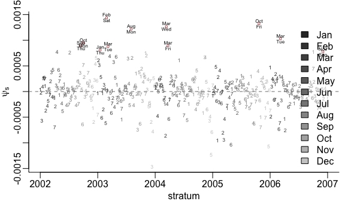

```r
oldpar <- par(no.readonly = TRUE)
par(mar = c(2.5, 2.5, 1, 0.5), bty = "l", mgp = c(1.5, 0.5, 0))

parts <- strsplit(colnames(md$term_data$elgm_matrix), ".", fixed = TRUE)
stratum_info <- data.frame(
  year = as.integer(vapply(parts, `[[`, character(1L), 1L)),
  month = vapply(parts, `[[`, character(1L), 2L),
  dow = vapply(parts, `[[`, character(1L), 3L),
  stringsAsFactors = FALSE
)
stratum_info$month <- factor(stratum_info$month, levels = levels(london$month))
stratum_info$dow <- factor(stratum_info$dow, levels = levels(london$dow))
stratum_info$name <- paste(stratum_info$month, stratum_info$dow, sep = "\n")
stratum_info$num <- stratum_info$year +
  (as.integer(stratum_info$month) - 1) / 12 +
  0.1 * (as.integer(stratum_info$dow) - 1) / 7

Scol <- grey(seq(0.2, 0.8, length.out = 12))
stratum_info$pch <- as.character(as.integer(stratum_info$dow))
stratum_info$col <- Scol[as.integer(stratum_info$month)]
stratum_info$pch[drop_idx] <- "o"
stratum_info$col[drop_idx] <- "firebrick"

plot(
  stratum_info$num, psi,
  pch = stratum_info$pch,
  cex = 0.55, col = stratum_info$col,
  xlab = "stratum", ylab = expression(psi[s])
)

text(
  stratum_info$num[drop_idx], psi[drop_idx],
  stratum_info$name[drop_idx],
  cex = 0.5
)

legend("bottomright", legend = levels(stratum_info$month), fill = Scol, bty = "n", inset = 0)

abline(h = 0, lty = 2, col = "grey50")
```

```r
par(oldpar)
```

## Confirm by dropping nominated strata

`ad_pack_drop()` retapes the likelihood without the Approximate Most Influential Set (filtering the fit’s coarse observation shards). Keep the outer MLE fixed and re-optimize `gamma`. The resulting change in $\phi(80)$ is an exact finite-sample lower bound on the worst-case strata-removal effect (Broderick et al.).

```r
phi_from_gamma <- function(gamma) {
  sum(a * as.numeric(gamma))
}

pm_curve <- function(gamma, grid = seq(0, 100, by = 2)) {
  new_grid <- data.frame(pm10 = grid)
  design_list <- lapply(pm_terms, design, data = new_grid)
  design_list <- Filter(Negate(is.null), design_list)
  D <- as.matrix(do.call(cbind, design_list))
  g <- as.numeric(gamma)
  names(g) <- gamma_lab
  list(x = grid, f = as.numeric(D %*% g[colnames(D)]))
}

curve0 <- pm_curve(gamma_hat)

if (!length(drop_idx)) {
  phi_drop <- NA_real_
  curve1 <- NULL
  message("No strata dropped; skipping confirmation retape.")
} else {
  af_drop <- ad_pack_drop(fit, drop_idx, num_threads = vignette_num_threads)
  io_drop <- inner_opt(
    parameters = as.numeric(fit$par_info$mle_internal),
    gamma = gamma_hat,
    ad_pack = af_drop,
    control = list(report.level = 0, report.freq = 0),
    deriv = FALSE,
    return_hessians = FALSE,
    verbose = FALSE
  )
  gamma_drop <- as.numeric(io_drop$inner_opt$solution)
  phi_drop <- phi_from_gamma(gamma_drop)
  curve1 <- pm_curve(gamma_drop)
}

c(
  phi_full = phi_hat,
  phi_dropped = phi_drop,
  actual_change = if (is.finite(phi_drop)) phi_drop - phi_hat else NA_real_,
  approx_change = if (length(drop_idx)) amip_change else NA_real_
)
```

```
#>      phi_full   phi_dropped actual_change approx_change
#>   0.011166203  -0.001367806  -0.012534009  -0.011507652
```

## Refit without AMIP strata

Drop the nominated strata from the data and re-estimate the full outer MLE (smoothness and overdispersion included).

```r
elgm <- md$term_data$elgm_matrix
if (!length(drop_idx)) {
  fit_drop <- NULL
  phi_refit <- NA_real_
  message("No strata dropped; skipping refit.")
} else {
  in_drop <- Matrix::rowSums(elgm[, drop_idx, drop = FALSE]) > 0
  london_drop <- md$term_data$data[!in_drop, , drop = FALSE]
  c(
    n_full = nrow(md$term_data$data),
    n_drop = nrow(london_drop),
    n_strata_drop = length(drop_idx)
  )
  fit_drop <- adlaplace(
    formula = cc_formula,
    data = london_drop,
    config = list(
      num_threads = vignette_num_threads,
      num_shards = fit_num_shards
    ),
    control = list(
      maxit = fit_maxit,
      trace = 3,
      REPORT = 5
    ),
    verbose = FALSE,
    hessian = FALSE
  )
  phi_refit <- sum(a * fit_drop$gamma[names(a)])
  fit_drop$par_info[, c("label", "mle", "mle_internal")]
}
```

```
#> N = 4, M = 5 machine precision = 2.22045e-16
#> At X0, 0 variables are exactly at the bounds
#> At iterate     0  f=       5195.4  |proj g|=        10009
#> At iterate     5  f =       5192.6  |proj g|=        238.16
#> At iterate    10  f =       5192.3  |proj g|=        2919.5
#> Warning: inner_opt status is Radius of trust region is less than
#> stop.trust.radius; the Laplace approximation used this inner solution anyway
#> At iterate    15  f =       5190.4  |proj g|=        9.1964
#> At iterate    20  f =       5176.9  |proj g|=        410.28
#>
#> iterations 24
#> function evaluations 33
#> segments explored during Cauchy searches 24
#> BFGS updates skipped 0
#> active bounds at final generalized Cauchy point 0
#> norm of the final projected gradient 0.693662
#> final function value 5176.77
#>
#> F = 5176.77
#>                       label          mle  mle_internal
#> 1                 rh_linear 0.0005938911  0.0005938911
#> 2 all_dirichlet_multinom_sd 0.0154897143 -4.1675790664
#> 3                  pm10_iwp 0.0009891239 -6.9186909739
#> 4                 tmean_iwp 0.0093463415 -4.6727702908
```

```r
c(
  phi_full = phi_hat,
  phi_inner_drop = phi_drop,
  phi_refit = phi_refit
)
```

```
#>       phi_full phi_inner_drop      phi_refit
#>   0.0111662032  -0.0013678056  -0.0009615622
```

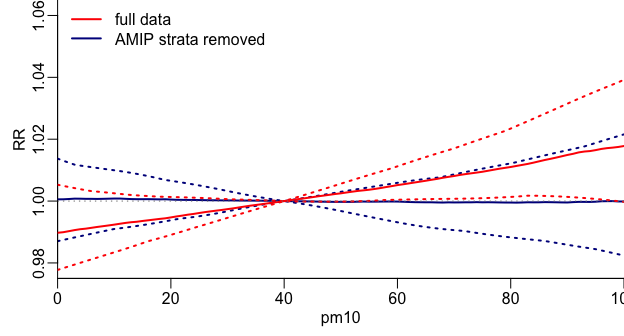

```r
num_sim <- 200L
num_grid <- 101L

sim_full <- sim_random(
  "pm10",
  fit = fit,
  num_grid = num_grid,
  num_sim = num_sim,
  transform = exp
)
q_full <- if (!is.null(sim_full$global)) sim_full$global else sim_full$pointwise

sim_drop <- NULL
q_drop <- NULL
if (!is.null(fit_drop)) {
  sim_drop <- sim_random(
    "pm10",
    fit = fit_drop,
    new_x = data.frame(pm10 = sim_full$x),
    num_sim = num_sim,
    transform = exp
  )
  q_drop <- if (!is.null(sim_drop$global)) sim_drop$global else sim_drop$pointwise
}


oldpar <- par(no.readonly = TRUE)
par(mar = c(3, 3, 0, 0), mgp = c(1.5, 0.5, 0), bty = "l")
matplot(
  sim_drop$x, q_drop,
  type = "l",
  lty = c(3, 1, 3), col = "darkblue", lwd = 2,
  xlab = "pm10", ylab = "RR", xaxs = "i",
  ylim = c(0.975, 1.065), yaxs = "i", bty = "l"
)

matlines(sim_full$x, q_full, lty = c(3, 1, 3), col = "red", lwd = 2)
abline(h = 1, lty = 3, col = "grey50")
legend(
  "topleft",
  legend = c("full data", "AMIP strata removed"),
  col = c("red", "darkblue"),
  lwd = 2,
  bty = "n"
)
```

```r
par(oldpar)
```

## Bacteria: sign-flip of the drug effect

The MASS `bacteria` data are 220 swabs on 50 children, with a three-level treatment (`placebo`, `drug`, `drug+`) and follow-up week. Treatment coefficients are placed in the inner field with known-SD Gaussian priors, so the drug-versus-placebo contrast is a coordinate of $\gamma$ and the same inner AMIP applies. There is no ELGM map, so `grad_obs_units` scores individual swabs. (Summing scores to children is not enough to flip this contrast under the linear approximation.)

```r
data(bacteria, package = "MASS")
bacteria$present <- as.integer(bacteria$y == "y")
bac_formula <- binom(present) ~
  intercept(sd = 10) +
  linear(trt, sd = 10) +
  linear(week, sd = 10) +
  iid(ID, init = 1) +
  prior(theta = 0, dist = "exp", median = 1)
bac_maxit <- if (vignette_full) 200L else 80L
bac_shards <- if (vignette_full) 20L else 8L
```

```r
fit_bac <- adlaplace(
  formula = bac_formula,
  data = bacteria,
  config = list(
    num_threads = vignette_num_threads,
    num_shards = bac_shards
  ),
  control = list(
    maxit = bac_maxit,
    trace = 3,
    REPORT = 5
  ),
  verbose = FALSE,
  hessian = FALSE
)
```

```
#> N = 1, M = 5 machine precision = 2.22045e-16
#> At X0, 0 variables are exactly at the bounds
#> At iterate     0  f=       115.38  |proj g|=       2.1965
#> At iterate     5  f =       115.07  |proj g|=    2.4532e-05
#>
#> iterations 5
#> function evaluations 7
#> segments explored during Cauchy searches 5
#> BFGS updates skipped 0
#> active bounds at final generalized Cauchy point 0
#> norm of the final projected gradient 2.45318e-05
#> final function value 115.069
#>
#> F = 115.069
```

```r
md_bac <- fit_bac$model_data
n_obs_bac <- n_obs_units(fit_bac)
gamma_lab_bac <- md_bac$term_data$info$gamma$gamma_label
trt_labs <- grep("^trt_linear_", gamma_lab_bac, value = TRUE)
drug_lab <- trt_labs[endsWith(trt_labs, "drug")]
if (!length(drug_lab)) {
  drug_lab <- trt_labs[[1L]]
}
fit_bac$par_info[, c("label", "mle", "mle_internal")]
```

```
#>    label      mle mle_internal
#> 1 ID_iid 1.292995    0.2569615
```

Swab-level scores via the same helpers as the case-crossover example.

```r
a_bac <- phi_gamma(fit_bac, coef = drug_lab)
inf_bac <- influence_scores(fit_bac, a_bac, batch_size = 32L)
gamma_hat_bac <- inf_bac$gamma_hat
phi_hat_bac <- inf_bac$phi
psi_bac <- inf_bac$psi
c(target = drug_lab, phi_hat = phi_hat_bac, n_swabs = n_obs_bac)
```

```
#>               target              phi_hat              n_swabs
#> "trt_linear_trtdrug"  "-1.15406057309466"                "220"
```

```r
summary(psi_bac)
```

```
#>       Min.    1st Qu.     Median       Mean    3rd Qu.       Max.
#> -0.0714118 -0.0093329 -0.0014039 -0.0003902  0.0068631  0.0994313
```

```r
S_bac <- amip_set(psi_bac, phi_hat_bac)
drop_idx_bac <- S_bac$idx
amip_alpha_bac <- S_bac$alpha
amip_change_bac <- S_bac$approx_change

c(
  phi_hat = phi_hat_bac,
  n_drop = length(drop_idx_bac),
  alpha = amip_alpha_bac,
  approx_change = amip_change_bac
)
```

```
#>       phi_hat        n_drop         alpha approx_change
#>    -1.1540606    37.0000000     0.1681818     1.1564267
```

```r
dropped_bac <- md_bac$term_data$data[drop_idx_bac, c("ID", "week", "trt"), drop = FALSE]
dropped_bac$psi <- psi_bac[drop_idx_bac]
table(dropped_bac$trt)
```

```
#>
#> placebo    drug   drug+
#>      19      18       0
```

```r
xtabs(~ week + trt, dropped_bac)
```

```
#>     trt
#> week placebo drug drug+
#>   0        1    2     0
#>   2        4    2     0
#>   4        0    5     0
#>   6        4    5     0
#>   11      10    4     0
```

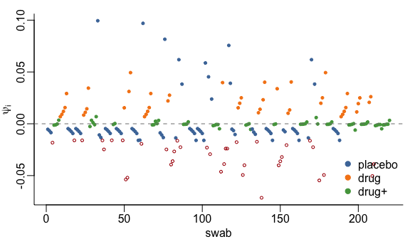

```r
oldpar <- par(no.readonly = TRUE)
par(mar = c(2.5, 2.5, 1, 0.5), bty = "l", mgp = c(1.5, 0.5, 0))
dat_bac <- md_bac$term_data$data
trt_cols <- c(placebo = "#4C78A8", drug = "#F58518", "drug+" = "#54A24B")
pch_bac <- rep(19, n_obs_bac)
col_bac <- unname(trt_cols[as.character(dat_bac$trt)])
pch_bac[drop_idx_bac] <- 1
col_bac[drop_idx_bac] <- "firebrick"

plot(
  seq_len(n_obs_bac), psi_bac,
  pch = pch_bac, cex = 0.55, col = col_bac,
  xlab = "swab", ylab = expression(psi[i])
)
legend(
  "bottomright",
  legend = names(trt_cols),
  col = trt_cols, pch = 19, bty = "n", inset = 0
)
abline(h = 0, lty = 2, col = "grey50")
```

```r
par(oldpar)
```

Inner confirmation drops the nominated swabs with `ad_pack_drop()`, keeps $\theta$ at the original MLE, and re-optimizes $\gamma$.

```r
if (!length(drop_idx_bac)) {
  phi_drop_bac <- NA_real_
  gamma_drop_bac <- NULL
  message("No swabs dropped; skipping confirmation retape.")
} else {
  af_drop_bac <- ad_pack_drop(
    fit_bac,
    drop_idx_bac,
    num_threads = vignette_num_threads
  )
  io_drop_bac <- inner_opt(
    parameters = as.numeric(fit_bac$par_info$mle_internal),
    gamma = gamma_hat_bac,
    ad_pack = af_drop_bac,
    control = list(report.level = 0, report.freq = 0),
    deriv = FALSE,
    return_hessians = FALSE,
    verbose = FALSE
  )
  gamma_drop_bac <- as.numeric(io_drop_bac$inner_opt$solution)
  names(gamma_drop_bac) <- names(gamma_hat_bac)
  phi_drop_bac <- sum(a_bac * gamma_drop_bac)
}

c(
  phi_full = phi_hat_bac,
  phi_dropped = phi_drop_bac,
  actual_change = if (is.finite(phi_drop_bac)) phi_drop_bac - phi_hat_bac else NA_real_,
  approx_change = if (length(drop_idx_bac)) amip_change_bac else NA_real_
)
```

```
#>      phi_full   phi_dropped actual_change approx_change
#>     -1.154061      5.162091      6.316152      1.156427
```

```r
if (!length(drop_idx_bac)) {
  fit_bac_drop <- NULL
  phi_refit_bac <- NA_real_
  message("No swabs dropped; skipping refit.")
} else {
  bacteria_drop <- md_bac$term_data$data[-drop_idx_bac, , drop = FALSE]
  c(
    n_full = nrow(md_bac$term_data$data),
    n_keep = nrow(bacteria_drop),
    n_swab_drop = length(drop_idx_bac)
  )
  fit_bac_drop <- adlaplace(
    formula = bac_formula,
    data = bacteria_drop,
    config = list(
      num_threads = vignette_num_threads,
      num_shards = bac_shards
    ),
    control = list(
      maxit = bac_maxit,
      trace = 3,
      REPORT = 5
    ),
    verbose = FALSE,
    hessian = FALSE
  )
  phi_refit_bac <- unname(fit_bac_drop$gamma[[drug_lab]])
  fit_bac_drop$par_info[, c("label", "mle", "mle_internal")]
}
```

```
#> N = 1, M = 5 machine precision = 2.22045e-16
#> At X0, 0 variables are exactly at the bounds
#> At iterate     0  f=       72.158  |proj g|=       3.0927
#> At iterate     5  f =       71.093  |proj g|=    0.00020309
#>
#> iterations 7
#> function evaluations 9
#> segments explored during Cauchy searches 7
#> BFGS updates skipped 0
#> active bounds at final generalized Cauchy point 0
#> norm of the final projected gradient 3.63687e-08
#> final function value 71.0926
#>
#> F = 71.0926
#>    label      mle mle_internal
#> 1 ID_iid 1.768907    0.5703617
```

```r
c(
  phi_full = phi_hat_bac,
  phi_inner_drop = phi_drop_bac,
  phi_refit = phi_refit_bac
)
```

```
#>       phi_full phi_inner_drop      phi_refit
#>      -1.154061       5.162091       5.099038
```

Treatment logit effects with 80% pointwise intervals from the inner Laplace approximation. The targeted drug-versus-placebo contrast is the first pair.

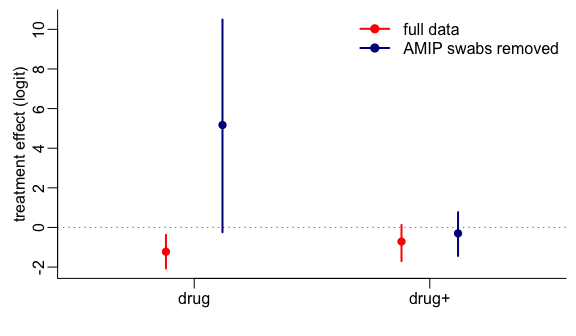

```r
num_sim_bac <- if (vignette_full) 200L else 80L
sims_bac <- rmvnldl(n = num_sim_bac, fit = fit_bac)
q_trt <- function(sims, labs, probs = c(0.1, 0.5, 0.9)) {
  apply(sims[, labs, drop = FALSE], 2L, stats::quantile, probs = probs)
}
q_full_bac <- q_trt(sims_bac, trt_labs)
q_drop_bac <- NULL
if (!is.null(fit_bac_drop)) {
  sims_bac_drop <- rmvnldl(n = num_sim_bac, fit = fit_bac_drop)
  q_drop_bac <- q_trt(sims_bac_drop, trt_labs)
}

pretty_trt <- sub("^trt_linear_trt", "", trt_labs)
ylim_bac <- range(q_full_bac, 0, finite = TRUE)
if (!is.null(q_drop_bac)) {
  ylim_bac <- range(ylim_bac, q_drop_bac, finite = TRUE)
}
oldpar <- par(no.readonly = TRUE)
par(mar = c(3, 3, 0.5, 0.5), mgp = c(1.5, 0.5, 0), bty = "l")
plot(
  NA, NA,
  xlim = c(0.5, length(trt_labs) + 0.5),
  ylim = ylim_bac,
  xaxt = "n", xlab = "", ylab = "treatment effect (logit)"
)
axis(1, at = seq_along(trt_labs), labels = pretty_trt)
abline(h = 0, lty = 3, col = "grey50")
offset <- if (is.null(q_drop_bac)) 0 else 0.12
for (j in seq_along(trt_labs)) {
  x0 <- j - offset
  arrows(x0, q_full_bac[1L, j], x0, q_full_bac[3L, j], length = 0, col = "red", lwd = 2)
  points(x0, q_full_bac[2L, j], pch = 19, col = "red")
  if (!is.null(q_drop_bac)) {
    x1 <- j + offset
    arrows(x1, q_drop_bac[1L, j], x1, q_drop_bac[3L, j], length = 0, col = "darkblue", lwd = 2)
    points(x1, q_drop_bac[2L, j], pch = 19, col = "darkblue")
  }
}
legend(
  "topright",
  legend = c("full data", "AMIP swabs removed"),
  col = c("red", "darkblue"),
  pch = 19, lwd = 2, bty = "n"
)
```

```r
par(oldpar)
```

## Notes

- Case-crossover removal units are **strata** (year–month–day-of-week matched sets), not individual calendar days. Bacteria removal units are **swabs** (rows of the observation vector). Use `n_obs_units()` for the domain size.
- The inner confirmation keeps outer parameters at the original MLE: that is sensitivity of $\hat\gamma(\beta,\theta)$, not a refit of smoothness or overdispersion. The refit chunks re-estimate the full outer MLE on the reduced data.
- Scores use streaming one-unit observation tapes (`grad_obs_units` inside `influence_scores`); $H$ comes from the fit pack via `inner_opt`. Confirmation retapes a filtered likelihood with `ad_pack_drop()`.
- The bacteria example needs **MASS**. Those chunks are skipped when it is not installed.